# R Notebook

#Análise de Correspondência Simples

Hoje vamos fazer uma análise de correspondência simples de Commodites adquiridas em todo o estado de Maharashtra (Índia)

Link para o dataset Original: *https://www.kaggle.com/samextensibleenergy/agricultural-commodity-dataset*

Primeiro vamos importar as libs necessárias

Agora ler os dados da nossa base de dados.

|  | APMC | Commodity | Year | Month | arrivals_in_qtl | min_price | max_price | modal_price | date | district_name | state_name |
| --- | --- | --- | --- | --- | --- | --- | --- | --- | --- | --- | --- |
| 1 | Ahmednagar | Bajri | 2015 | April | 79 | 1406 | 1538 | 1463 | 2015-04 | Ahmadnagar | Maharashtra |
| 2 | Ahmednagar | Bajri | 2016 | April | 106 | 1788 | 1925 | 1875 | 2016-04 | Ahmadnagar | Maharashtra |
| 3 | Ahmednagar | Wheat(Husked) | 2015 | April | 1253 | 1572 | 1890 | 1731 | 2015-04 | Ahmadnagar | Maharashtra |
| 4 | Ahmednagar | Wheat(Husked) | 2016 | April | 387 | 1750 | 2220 | 1999 | 2016-04 | Ahmadnagar | Maharashtra |
| 5 | Ahmednagar | Sorgum(Jawar) | 2015 | April | 3825 | 1600 | 2200 | 1900 | 2015-04 | Ahmadnagar | Maharashtra |
| 6 | Ahmednagar | Sorgum(Jawar) | 2016 | April | 2093 | 1695 | 2454 | 2119 | 2016-04 | Ahmadnagar | Maharashtra |

Agora vamos visualizar alguns dados. Como a base é muito grande limitaremos à 1000 observações.

| APMC | Commodity | Year | Month | arrivals_in_qtl | min_price | max_price | modal_price | date | district_name | state_name |
| --- | --- | --- | --- | --- | --- | --- | --- | --- | --- | --- |
| Ahmednagar | Bajri | 2015 | April | 79 | 1406 | 1538 | 1463 | 2015-04 | Ahmadnagar | Maharashtra |
| Ahmednagar | Bajri | 2016 | April | 106 | 1788 | 1925 | 1875 | 2016-04 | Ahmadnagar | Maharashtra |
| Ahmednagar | Wheat(Husked) | 2015 | April | 1253 | 1572 | 1890 | 1731 | 2015-04 | Ahmadnagar | Maharashtra |
| Ahmednagar | Wheat(Husked) | 2016 | April | 387 | 1750 | 2220 | 1999 | 2016-04 | Ahmadnagar | Maharashtra |
| Ahmednagar | Sorgum(Jawar) | 2015 | April | 3825 | 1600 | 2200 | 1900 | 2015-04 | Ahmadnagar | Maharashtra |
| Ahmednagar | Sorgum(Jawar) | 2016 | April | 2093 | 1695 | 2454 | 2119 | 2016-04 | Ahmadnagar | Maharashtra |
| Ahmednagar | Maize | 2015 | April | 75 | 1345 | 1401 | 1373 | 2015-04 | Ahmadnagar | Maharashtra |
| Ahmednagar | Maize | 2016 | April | 155 | 1367 | 1392 | 1375 | 2016-04 | Ahmadnagar | Maharashtra |
| Ahmednagar | Gram | 2015 | April | 1794 | 3533 | 3762 | 3647 | 2015-04 | Ahmadnagar | Maharashtra |
| Ahmednagar | Gram | 2016 | April | 630 | 4790 | 5553 | 5216 | 2016-04 | Ahmadnagar | Maharashtra |
| Ahmednagar | Horse Gram | 2015 | April | 3 | 7150 | 7150 | 7150 | 2015-04 | Ahmadnagar | Maharashtra |
| Ahmednagar | Matki | 2015 | April | 1 | 7500 | 7500 | 7500 | 2015-04 | Ahmadnagar | Maharashtra |
| Ahmednagar | Pigeon Pea (Tur) | 2015 | April | 144 | 4993 | 5373 | 5233 | 2015-04 | Ahmadnagar | Maharashtra |
| Ahmednagar | Pigeon Pea (Tur) | 2016 | April | 33 | 6900 | 7700 | 7329 | 2016-04 | Ahmadnagar | Maharashtra |
| Ahmednagar | Black Gram | 2015 | April | 7 | 5700 | 5700 | 5700 | 2015-04 | Ahmadnagar | Maharashtra |
| Ahmednagar | Black Gram | 2016 | April | 2 | 7500 | 7500 | 7500 | 2016-04 | Ahmadnagar | Maharashtra |
| Ahmednagar | Castor Seed | 2015 | April | 3 | 3313 | 3313 | 3313 | 2015-04 | Ahmadnagar | Maharashtra |
| Ahmednagar | Soybean | 2015 | April | 12 | 2900 | 3400 | 3150 | 2015-04 | Ahmadnagar | Maharashtra |
| Ahmednagar | Soybean | 2016 | April | 20 | 2200 | 3900 | 3603 | 2016-04 | Ahmadnagar | Maharashtra |
| Ahmednagar | Jaggery | 2016 | April | 2611 | 2950 | 3550 | 3263 | 2016-04 | Ahmadnagar | Maharashtra |
| Ahmednagar | Lemon | 2016 | April | 106 | 2750 | 6625 | 5500 | 2016-04 | Ahmadnagar | Maharashtra |
| Ahmednagar | Ginger (Fresh) | 2016 | April | 46 | 1667 | 3000 | 2500 | 2016-04 | Ahmadnagar | Maharashtra |
| Ahmednagar | Potato | 2016 | April | 510 | 767 | 1367 | 1133 | 2016-04 | Ahmadnagar | Maharashtra |
| Ahmednagar | Ladies Finger | 2016 | April | 58 | 1067 | 4000 | 3000 | 2016-04 | Ahmadnagar | Maharashtra |
| Ahmednagar | Flower | 2016 | April | 180 | 625 | 3375 | 2138 | 2016-04 | Ahmadnagar | Maharashtra |
| Ahmednagar | Carrot | 2016 | April | 57 | 900 | 1400 | 1250 | 2016-04 | Ahmadnagar | Maharashtra |
| Ahmednagar | Cluster Bean | 2016 | April | 46 | 4250 | 6875 | 5750 | 2016-04 | Ahmadnagar | Maharashtra |
| Ahmednagar | Ghevda | 2016 | April | 3 | 4500 | 6000 | 5250 | 2016-04 | Ahmadnagar | Maharashtra |
| Ahmednagar | Ghosali(Bhaji) | 2016 | April | 5 | 1333 | 3667 | 2833 | 2016-04 | Ahmadnagar | Maharashtra |
| Ahmednagar | Mango(Raw) | 2016 | April | 23 | 1000 | 2000 | 1500 | 2016-04 | Ahmadnagar | Maharashtra |

[output cut: 970 more lines]

Temos alguns dados interessantes. Faremos nossa análise com duas variáveis desse dataset:

*Commodity - Bem de origem primária comercializado em bolsas de mercadorias e valores.* Year - Ano em que foram registrados os dados.

Vamos iniciar verificando os valores únicos dos anos.

```r
unique(dados_agricultura$Year)
```

```
[1] 2015 2016 2014
```

ótimo. Temos 3 anos na análise. Agora vamos verificar os valores únicos das Commodities.

```r
unique(dados_agricultura$Commodity)
```

```
  [1] "Bajri"                 "Wheat(Husked)"         "Sorgum(Jawar)"         "Maize"
  [5] "Gram"                  "Horse Gram"            "Matki"                 "Pigeon Pea (Tur)"
  [9] "Black Gram"            "Castor Seed"           "Soybean"               "Jaggery"
 [13] "Lemon"                 "Ginger (Fresh)"        "Potato"                "Ladies Finger"
 [17] "Flower"                "Carrot"                "Cluster Bean"          "Ghevda"
 [21] "Ghosali(Bhaji)"        "Mango(Raw)"            "Cucumber"              "Onion"
 [25] "Bitter Gourd"          "Cabbage"               "Garlic"                "Math (Bhaji)"
 [29] "Capsicum"              "Tomato"                "Brinjal"               "Tamarind"
 [33] "Tamarind Seed"         "Coriander (Dry)"       "Green Chilli"          "Chillies(Red)"
 [37] "Mustard"               "Paddy-Unhusked"        "Hilda"                 "Chikoo"
 [41] "Cotton"                "Ground Nut Pods (Dry)" "Pomegranate"           "Papai"
 [45] "Melon"                 "Beet Root"             "Bottle Gourd"          "Dhemse"
 [49] "Coriander "            "Coriander  "           "Spinach"               "Shevga"
 [53] "Small Gourd"           "Grapes"                "Kharbuj"               "Green Gram"
 [57] "Sunflower"             "Safflower"             "Mango"                 "Water Melon"
```

[output cut: 73 more lines]

Agora a situação ficou um pouco mais complicada.Temos 2 problemas:

1. Nossos dados não estão devidamente tratados. Existem Commodities com mesmo nome porém uns escritos em maiuscula e outros em minusculo. Vamos padronizar! No nosso exemplo deixarei tudo minusculo.
2. Existem muitas commodities. Para plotar esses dados teremos problemas da forma como está. Nesse caso podemos avaliar as commodities com maiores relevâncias (mais ocorrências) visto que estamos compras em diferentes períodos.

Vamos então tratar nossos dados.

| Commodity | Quantidade |
| --- | --- |
| gram | 4115 |
| wheat(husked) | 4097 |
| soybean | 3727 |
| sorgum(jawar) | 3716 |
| pigeon pea (tur) | 3477 |
| maize | 2546 |
| green gram | 2425 |
| bajri | 2346 |
| onion | 1872 |
| black gram | 1675 |

[output cut: 194 more lines]

Agora vamos filtrar no nosso dataset original. Para esse exemplo vamos considerar as 15 Commodities com mais ocorrências.

|  | APMC | Commodity | Year | Month | arrivals_in_qtl | min_price | max_price | modal_price | date | district_name | state_name |
| --- | --- | --- | --- | --- | --- | --- | --- | --- | --- | --- | --- |
| 1 | Ahmednagar | bajri | 2015 | April | 79 | 1406 | 1538 | 1463 | 2015-04 | Ahmadnagar | Maharashtra |
| 2 | Ahmednagar | bajri | 2016 | April | 106 | 1788 | 1925 | 1875 | 2016-04 | Ahmadnagar | Maharashtra |
| 3 | Ahmednagar | wheat(husked) | 2015 | April | 1253 | 1572 | 1890 | 1731 | 2015-04 | Ahmadnagar | Maharashtra |
| 4 | Ahmednagar | wheat(husked) | 2016 | April | 387 | 1750 | 2220 | 1999 | 2016-04 | Ahmadnagar | Maharashtra |
| 5 | Ahmednagar | sorgum(jawar) | 2015 | April | 3825 | 1600 | 2200 | 1900 | 2015-04 | Ahmadnagar | Maharashtra |
| 6 | Ahmednagar | sorgum(jawar) | 2016 | April | 2093 | 1695 | 2454 | 2119 | 2016-04 | Ahmadnagar | Maharashtra |
| 7 | Ahmednagar | maize | 2015 | April | 75 | 1345 | 1401 | 1373 | 2015-04 | Ahmadnagar | Maharashtra |
| 8 | Ahmednagar | maize | 2016 | April | 155 | 1367 | 1392 | 1375 | 2016-04 | Ahmadnagar | Maharashtra |
| 9 | Ahmednagar | gram | 2015 | April | 1794 | 3533 | 3762 | 3647 | 2015-04 | Ahmadnagar | Maharashtra |
| 10 | Ahmednagar | gram | 2016 | April | 630 | 4790 | 5553 | 5216 | 2016-04 | Ahmadnagar | Maharashtra |

[output cut: 990 more lines]

Perfeito, finalizamos nossos tratamentos iniciais. Podemos inicializar a análise. A análise de Correspondência inicia primeiramente com uma tabela de frequência com nossas duas variáveis.

```r
tabela_frequencia
```

```
                        2014 2015 2016
  bajri                  318  950 1078
  black gram             272  655  748
  brinjal                125  393  490
  cotton                 189  473  401
  gram                   504 1707 1904
  green gram             384  986 1055
  ground nut pods (dry)  156  436  476
  ladies finger          116  360  445
  maize                  300 1046 1200
  onion                  236  769  867
  pigeon pea (tur)       360 1441 1676
  sorgum(jawar)          465 1551 1700
  soybean                512 1542 1673
  tomato                 130  406  485
  wheat(husked)          545 1762 1790
```

Agora temos que avaliar se nossas variáveis não se relacionam de forma aleatória.Para isso vamos utilizar da nossa tabela de frequência para descobrir nosso teste estátistico chi2. Para o exemplo utilizaremos um nível de significância de 0.05% (Padrão, 5%). Se o p-value for inferior à esse nível, podemos aceitar a hipótese alternativa.

```r
qui2
```

```
    Pearson's Chi-squared test

data:  tabela_frequencia
X-squared = 118.99, df = 28, p-value = 3.47e-13
```

Confirmamos que nossas variáveis não se relacionam de forma aleatória. Portanto podemos prosseguir.

Agora avaliaremos como as categorias presentes na nossa amostra se relacionam através dos resíduos padronizados ajustados.

Relações positivas no nível de significância de 5% devem ser maiores que 1,96 positivos. Para maiores detalhes e valores para outros níveis consultar uma tabela z.

Ex: Se a compra de cebolas (Onion) foi grande no ano de 2016, a relação será positiva,

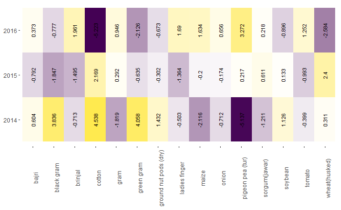

OBS: Ao interpretar um mapa perceptual, utilizar sempre a tabela de resíduos proveniente. Em casos onde se há muitas dimensões geradas, Podem haver erros ao interpretar o mapa, visto que ele é somente bidimensional.

Agora vamos rodar nossa análise de correspondência.

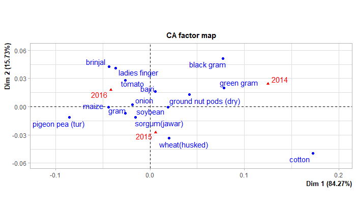

Verificando os autovalores gerados

```r
anacor$eig
```

```
        eigenvalue percentage of variance cumulative percentage of variance
dim 1 0.0028587423               84.27339                          84.27339
dim 2 0.0005334818               15.72661                         100.00000
```

Coordenadas das linhas (Commodity)

```r
anacor$row$coord
```

```
                            Dim 1         Dim 2
bajri                  0.00578622  0.0164024359
black gram             0.07711794  0.0514081897
brinjal               -0.04354092  0.0425333997
cotton                 0.17294670 -0.0496588672
gram                  -0.02619861 -0.0067330613
green gram             0.07831920  0.0197918327
ground nut pods (dry)  0.04148913  0.0130089944
ladies finger         -0.03660246  0.0411432831
maize                 -0.04421307 -0.0002866746
onion                 -0.01858498  0.0022044920
pigeon pea (tur)      -0.08557880 -0.0114814509
sorgum(jawar)         -0.01565115 -0.0109730647
soybean                0.01927168 -0.0002779906
tomato                -0.02631265  0.0282920779
wheat(husked)          0.02018501 -0.0335124488
```

Coordenadas das colunas (Anos)

```r
anacor$col$coord
```

```
            Dim 1       Dim 2
2014  0.125180906  0.02448820
2015  0.005920476 -0.02743310
2016 -0.041471420  0.01777642
```

Como as coordenadas são dadas em objetos separados, vamos unir todas em um único objeto.

```r
coordenadas_linhas_colunas
```

```
                             Dim 1         Dim 2
bajri                  0.005786220  0.0164024359
black gram             0.077117942  0.0514081897
brinjal               -0.043540923  0.0425333997
cotton                 0.172946701 -0.0496588672
gram                  -0.026198615 -0.0067330613
green gram             0.078319196  0.0197918327
ground nut pods (dry)  0.041489128  0.0130089944
ladies finger         -0.036602455  0.0411432831
maize                 -0.044213067 -0.0002866746
onion                 -0.018584976  0.0022044920
pigeon pea (tur)      -0.085578802 -0.0114814509
sorgum(jawar)         -0.015651149 -0.0109730647
soybean                0.019271679 -0.0002779906
tomato                -0.026312646  0.0282920779
wheat(husked)          0.020185008 -0.0335124488
2014                   0.125180906  0.0244881996
2015                   0.005920476 -0.0274330994
2016                  -0.041471420  0.0177764200
```

Otimo. Falta pouco para montarmos nosso mapa. Mas agora que juntamos tudo num único objeto como o algortimo saberá o que é linha e coluna? Vamos adicionar essas informações com base na nossa base de dados filtrada.

```r
quantidade_categorias
```

```
Commodity      Year
       15         3
```

Juntando todas as informações no mesmo objeto.

|  | Dim.1 | Dim.2 | variavel |
| --- | --- | --- | --- |
| bajri | 0.005786220 | 0.0164024359 | Commodity |
| black gram | 0.077117942 | 0.0514081897 | Commodity |
| brinjal | -0.043540923 | 0.0425333997 | Commodity |
| cotton | 0.172946701 | -0.0496588672 | Commodity |
| gram | -0.026198615 | -0.0067330613 | Commodity |
| green gram | 0.078319196 | 0.0197918327 | Commodity |
| ground nut pods (dry) | 0.041489128 | 0.0130089944 | Commodity |
| ladies finger | -0.036602455 | 0.0411432831 | Commodity |
| maize | -0.044213067 | -0.0002866746 | Commodity |
| onion | -0.018584976 | 0.0022044920 | Commodity |

[output cut: 8 more lines]

Vamos ver como ficou nosso mapa perceptual

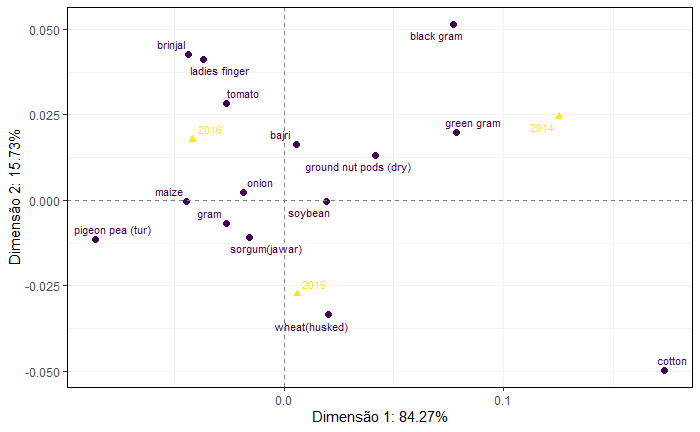